# Report_Chapter8

Chiara Huwiler

2023-05-01

## AGDS 8.5 Report Exercises

```r
# Set up
library(ggplot2)
library(tidyverse)
```

# Linear regression

```r
# Load data
df_regression <- readr::read_csv("./data/df_for_stepwise_regression.csv")
```

## Evaluation of all bivariate model

Task: An evaluation of all bivariate models (single predictor), implementing just steps 1-3 of the algorithm described in 8.2.3.1. This should be complemented by a visualisation and a brief discussion of the results. Steps in 8.2.3.1:

1. Set the number of predictors to be considered to p = 1 The code repeats over each predictor in the dataset, so it considers only one predictor at a time.

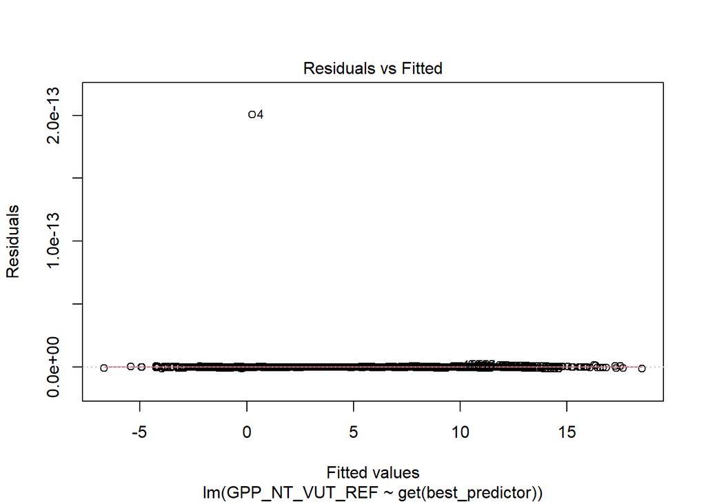

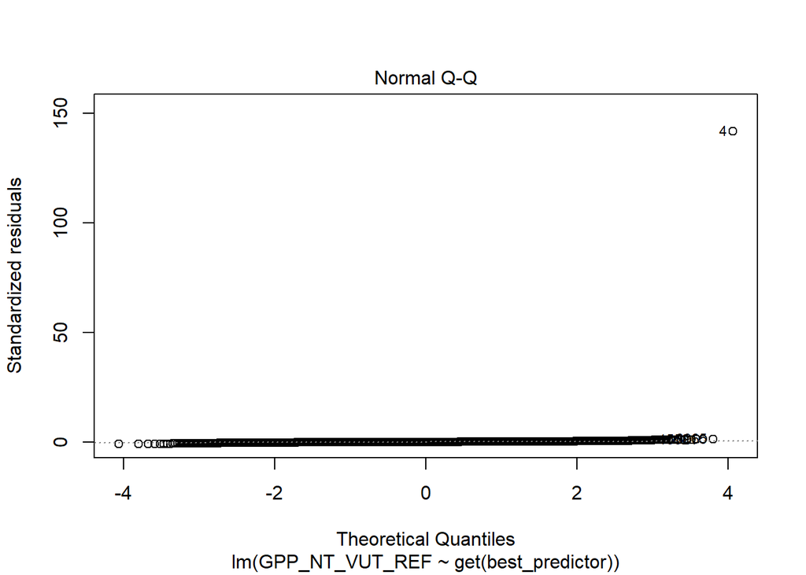

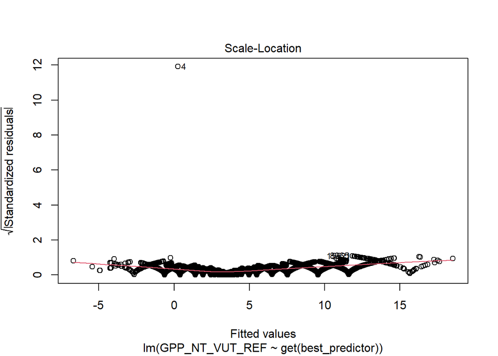

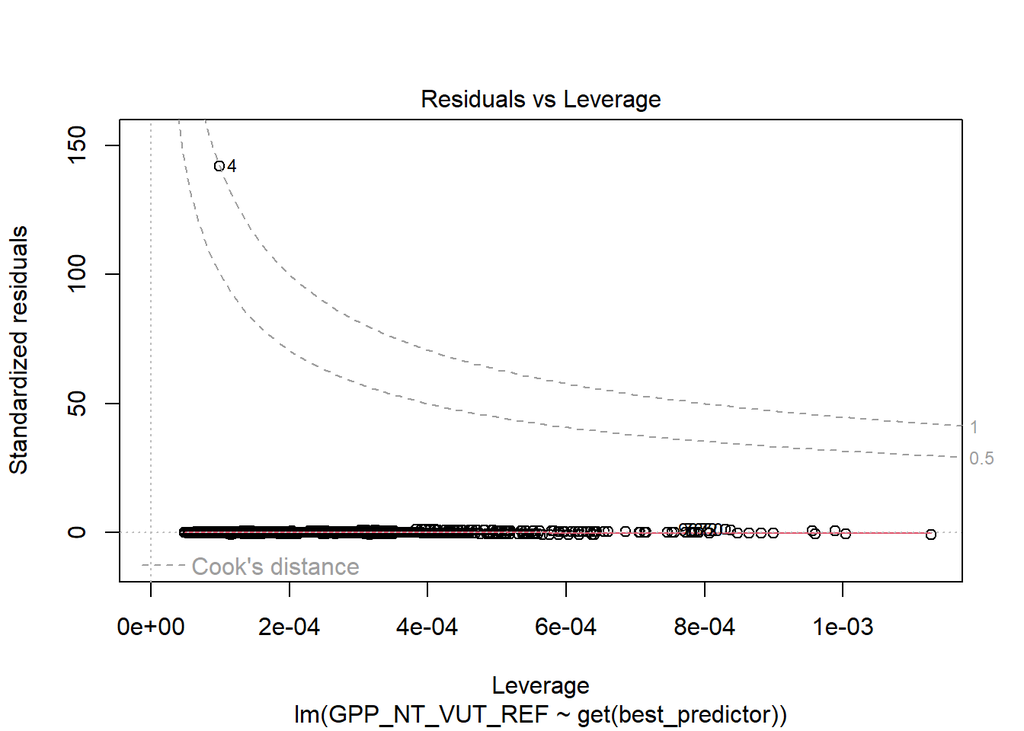

```
## Best predictor candidate: GPP_NT_VUT_REF
## Best R-squared value: 1
## AIC for best model: -1349310
```

```r
# 2. Fit all regression models with p predictors and compute their R^2

# Looping
# define a list of datasets or subsets of the same dataset
list_of_datasets <- list(df_regression)

# loop over the list of datasets
for (i in seq_along(list_of_datasets)) {

  # perform the regression analysis and save the results in a list
  storage_1 <- list()
  for (j in 1:length(names(list_of_datasets[[i]]))[-16]) {
    predictor <- names(list_of_datasets[[i]])[j]
    storage_1[[predictor]] <- lm(GPP_NT_VUT_REF ~ get(predictor), data = list_of_datasets[[i]])
  }
 # 3. Select the model with p predictors that achieves the highest R2^(best fitting model) and compute its AIC.

  # calculate the R2 values and save them in a vector
  r2values <- numeric(length(storage_1))
  for (k in 1:length(storage_1)) {
    r2values[k] <- summary(storage_1[[k]])$r.squared
  }

  # get the index of the best model based on R2 value
  max_index <- which.max(r2values)

  # fit the best model and calculate AIC
  best_predictor <- names(list_of_datasets[[i]])[max_index]
  best_model <- lm(GPP_NT_VUT_REF ~ get(best_predictor), data = list_of_datasets[[i]])
  AIC_value <- AIC(best_model)

  # plot the best model
  plot(best_model)

  # print the best predictor and its corresponding R-squared value and AIC
  cat("Best predictor candidate:", best_predictor, "\n")
  cat("Best R-squared value:", r2values[max_index], "\n")
  cat("AIC for best model:", AIC_value, "\n")
}
```